# Analysis Preview

2022-12-17

```r
library(png)
library(grid)
library(ggplot2)
library(xtable)
```

```r
# Seed for random number generation
set.seed(42)
knitr::opts_chunk$set(cache.extra = knitr::rand_seed)
```

# Results

## Do we extend previous work reporting a preference for taxonomic matching in the US and thematic matching in Asia?

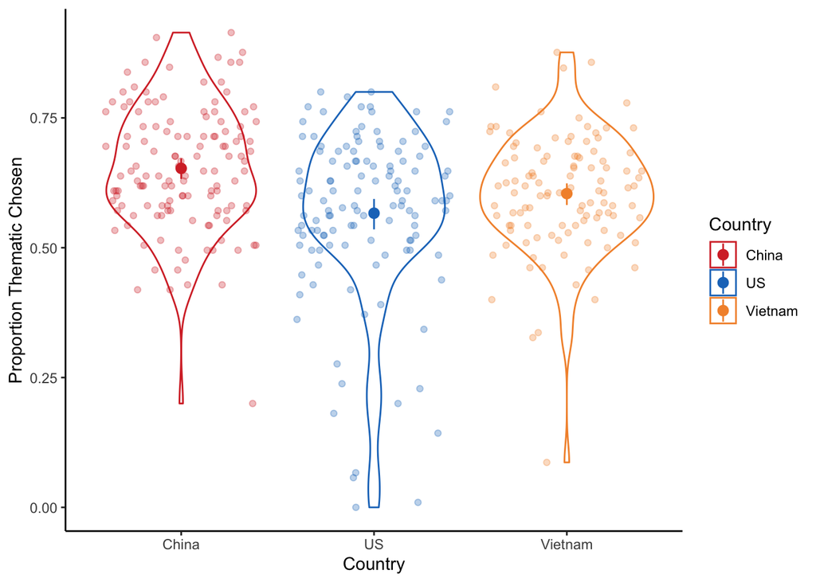

Proportion of thematic responses by country. Only US-China responding comparison shows a siginficant difference. We could not extend this to US-Vietnam responding comparison.

```r
# df.country_sum <- df.country %>%
#   group_by(country) %>%
#   summarize(mean_theme_resp_percent = mean(theme_resp_percent),
#             sd_theme_resp_percent = sd(theme_resp_percent))

fit.country = glmer(responses_theme ~ country + (1 | subject) + (country | triad),
                    data = df,
                    family = "binomial")
summary(fit.country)
fit.country.anova = Anova(fit.country, type=3)

fit.country_EN_VN = glmer(responses_theme ~ country + (1 | subject) + (country | triad),
                    data = df %>% filter(country != "China"),
                    family = "binomial")
summary(fit.country_EN_VN)
```

```
Generalized linear mixed model fit by maximum likelihood (Laplace
  Approximation) [glmerMod]
 Family: binomial  ( logit )
Formula: responses_theme ~ country + (1 | subject) + (country | triad)
   Data: df

     AIC      BIC   logLik deviance df.resid
 41859.8  41945.4 -20919.9  41839.8    38367

Scaled residuals:
    Min      1Q  Median      3Q     Max
-6.2906 -0.7181  0.3516  0.6339 13.5410

Random effects:
 Groups  Name           Variance Std.Dev. Corr
 subject (Intercept)    0.5683   0.7539
 triad   (Intercept)    0.9647   0.9822
         countryUS      0.6359   0.7975   -0.02
         countryVietnam 0.8303   0.9112   -0.08  0.31
Number of obs: 38377, groups:  subject, 366; triad, 105

Fixed effects:
               Estimate Std. Error z value Pr(>|z|)
(Intercept)      0.8025     0.1180   6.799 1.05e-11 ***
countryUS       -0.4989     0.1260  -3.959 7.52e-05 ***
countryVietnam  -0.2489     0.1356  -1.836   0.0664 .
---
Signif. codes:  0 '***' 0.001 '**' 0.01 '*' 0.05 '.' 0.1 ' ' 1

Correlation of Fixed Effects:
            (Intr) cntrUS
countryUS   -0.331
countryVtnm -0.339  0.401
Generalized linear mixed model fit by maximum likelihood (Laplace
  Approximation) [glmerMod]
 Family: binomial  ( logit )
Formula: responses_theme ~ country + (1 | subject) + (country | triad)
   Data: df %>% filter(country != "China")

     AIC      BIC   logLik deviance df.resid
```

[output cut: 8 more lines]

```
 subject (Intercept)    0.6855   0.828
 triad   (Intercept)    1.5874   1.260
         countryVietnam 1.0398   1.020    -0.37
Number of obs: 24517, groups:  subject, 234; triad, 105

Fixed effects:
               Estimate Std. Error z value Pr(>|z|)
(Intercept)      0.3008     0.1455   2.068   0.0387 *
countryVietnam   0.2519     0.1509   1.670   0.0950 .
---
Signif. codes:  0 '***' 0.001 '**' 0.01 '*' 0.05 '.' 0.1 ' ' 1

Correlation of Fixed Effects:
            (Intr)
countryVtnm -0.483
```

To test for cross-context differences in similarity judgments between the countries, we ran a mixed-effects logistic regression predicting triad responding (taxonomic or thematic) with country (US, China, or Vietnam) as a fixed effect. As random effects, we included an intercept per subject and one per triad, as well as by-triad random slopes for country to account for variation in the country effect across triads. In R syntax, the model is: response ~ country + (1 | subject) + (country | triad).

Overall, there is a significant effect of country on proportion of thematic responses ($\chi^2$(2) = 15.75, p < .001). However, this effect is driven by the difference between US and China responding ($\beta$ = -0.5, p < .001). There is no statistical difference between the Vietnam and China responding ($\beta$ = -0.25, p = 0.066), and the US and Vietnam responding ($\beta$ = 0.25, p = 0.095).

On this analysis, we do not find support that the US-China tendencies toward taxonomic and thematic responding (respectively) extend to the US-Vietnam comparison. Accordingly, we cannot speak to overall biases toward thematic responding across Asian cultural contexts broadly, but we do replicate the differences documented by @Ji2004 between the US and China. However, in our corpus model comparison, we do find evidence for different, more fine-grained variation in similarity judgments between the US and Vietnam.

## Can the differences in similarity judgments between English, Mandarin and Vietnamese speakers be explained by variation in lexical statistics?

### Is responding in each cultural context predicted by the corresponding lexical statistics?

To test whether variation in lexical co-occurrence can explain differences in similarity judgments between US and Vietnam participants, we compare logistic mixed-effects regression models fit to the thematic responding data from each country separately. We first ask how well each corpus model (English, Vietnamese, or Mandarin) predicts similarity judgments by speakers of the corresponding language (US, Vietnam, or China). To do this, we use a mixed-effects logistic regression to predict triad responses (0=taxonomic or 1=thematic) with corpus prediction (proportion thematic co-occurrence or cosine distance) as a fixed effect and participant and triad as random effects.

We found that all corpora are significant predictors of all cultural context responding.

```r
# English
fit.EN_US = glmer(responses_theme ~ theme_freq_prop_E + (1 | subject) + (1 | triad),
          data = df %>% filter(country == "US", !(triad %in% triads_omit)),
          family="binomial")
summary(fit.EN_US)
fit.EN_US.anova = Anova(fit.EN_US, type = 3)

#Vietnamese
fit.VI_US = glmer(responses_theme ~ theme_freq_prop_V + (1 | subject) + (1 | triad),
          data = df %>% filter(country == "US", !(triad %in% triads_omit)),
          family="binomial")
summary(fit.VI_US)
fit.VI_US.anova = Anova(fit.VI_US, type = 3)

#Mandarin
fit.ZH_US = glmer(responses_theme ~ theme_freq_prop_M + (1 | subject) + (1 | triad),
          data = df %>% filter(country == "US", !(triad %in% triads_omit)),
          family="binomial")
summary(fit.ZH_US)
fit.ZH_US.anova = Anova(fit.ZH_US, type = 3)
```

```
Generalized linear mixed model fit by maximum likelihood (Laplace
  Approximation) [glmerMod]
 Family: binomial  ( logit )
Formula: responses_theme ~ theme_freq_prop_E + (1 | subject) + (1 | triad)
   Data: df %>% filter(country == "US", !(triad %in% triads_omit))

     AIC      BIC   logLik deviance df.resid
 13974.4  14004.3  -6983.2  13966.4    13015

Scaled residuals:
    Min      1Q  Median      3Q     Max
-4.9495 -0.6809  0.3121  0.6286 15.4590

Random effects:
 Groups  Name        Variance Std.Dev.
 subject (Intercept) 0.9915   0.9957
 triad   (Intercept) 1.2845   1.1333
Number of obs: 13019, groups:  subject, 124; triad, 105

Fixed effects:
                  Estimate Std. Error z value Pr(>|z|)
(Intercept)        -0.8541     0.2711  -3.151  0.00163 **
theme_freq_prop_E   1.8414     0.3677   5.008  5.5e-07 ***
---
Signif. codes:  0 '***' 0.001 '**' 0.01 '*' 0.05 '.' 0.1 ' ' 1

Correlation of Fixed Effects:
            (Intr)
thm_frq_p_E -0.847
Generalized linear mixed model fit by maximum likelihood (Laplace
  Approximation) [glmerMod]
 Family: binomial  ( logit )
Formula: responses_theme ~ theme_freq_prop_V + (1 | subject) + (1 | triad)
   Data: df %>% filter(country == "US", !(triad %in% triads_omit))

     AIC      BIC   logLik deviance df.resid
 13982.9  14012.8  -6987.5  13974.9    13015

Scaled residuals:
    Min      1Q  Median      3Q     Max
```

[output cut: 32 more lines]

```
 Groups  Name        Variance Std.Dev.
 subject (Intercept) 0.9923   0.9961
 triad   (Intercept) 1.4396   1.1998
Number of obs: 13019, groups:  subject, 124; triad, 105

Fixed effects:
                  Estimate Std. Error z value Pr(>|z|)
(Intercept)        -0.4324     0.2564  -1.687  0.09168 .
theme_freq_prop_M   1.2154     0.3481   3.492  0.00048 ***
---
Signif. codes:  0 '***' 0.001 '**' 0.01 '*' 0.05 '.' 0.1 ' ' 1

Correlation of Fixed Effects:
            (Intr)
thm_frq_p_M -0.813
```

For US responding: English (EN), Vietnamese (VI), and Mandarin (ZH) corpus are all significant predictors. EN corpus: $\beta$ = 1.84, $\chi^2$(1) = 25.08, p < .001. VI corpus: $\beta$ = 1.27, $\chi^2$(1) = 14.71, p < .001. ZH corpus: $\beta$ = 1.22, $\chi^2$(1) = 12.19, p < .001.

```r
# English
fit.EN_VN = glmer(responses_theme ~ theme_freq_prop_E + (1 | subject) + (1 | triad),
          data = df %>% filter(country == "Vietnam", !(triad %in% triads_omit)),
          family="binomial")
summary(fit.EN_VN)
fit.EN_VN.anova = Anova(fit.EN_VN, type = 3)

#Vietnamese
fit.VI_VN = glmer(responses_theme ~ theme_freq_prop_V + (1 | subject) + (1 | triad),
          data = df %>% filter(country == "Vietnam", !(triad %in% triads_omit)),
          family="binomial")
summary(fit.VI_VN)
fit.VI_VN.anova = Anova(fit.VI_VN, type = 3)

#Mandarin
fit.ZH_VN = glmer(responses_theme ~ theme_freq_prop_M + (1 | subject) + (1 | triad),
          data = df %>% filter(country == "Vietnam", !(triad %in% triads_omit)),
          family="binomial")
summary(fit.ZH_VN)
fit.ZH_VN.anova = Anova(fit.ZH_VN, type = 3)
```

```
Generalized linear mixed model fit by maximum likelihood (Laplace
  Approximation) [glmerMod]
 Family: binomial  ( logit )
Formula: responses_theme ~ theme_freq_prop_E + (1 | subject) + (1 | triad)
   Data: df %>% filter(country == "Vietnam", !(triad %in% triads_omit))

     AIC      BIC   logLik deviance df.resid
 12492.8  12522.2  -6242.4  12484.8    11494

Scaled residuals:
    Min      1Q  Median      3Q     Max
-5.9469 -0.6799  0.3462  0.6211  5.1452

Random effects:
 Groups  Name        Variance Std.Dev.
 subject (Intercept) 0.3819   0.618
 triad   (Intercept) 1.3481   1.161
Number of obs: 11498, groups:  subject, 110; triad, 105

Fixed effects:
                  Estimate Std. Error z value Pr(>|z|)
(Intercept)        -0.6314     0.2691  -2.346    0.019 *
theme_freq_prop_E   1.8785     0.3774   4.977 6.44e-07 ***
---
Signif. codes:  0 '***' 0.001 '**' 0.01 '*' 0.05 '.' 0.1 ' ' 1

Correlation of Fixed Effects:
            (Intr)
thm_frq_p_E -0.876
Generalized linear mixed model fit by maximum likelihood (Laplace
  Approximation) [glmerMod]
 Family: binomial  ( logit )
Formula: responses_theme ~ theme_freq_prop_V + (1 | subject) + (1 | triad)
   Data: df %>% filter(country == "Vietnam", !(triad %in% triads_omit))

     AIC      BIC   logLik deviance df.resid
 12500.4  12529.8  -6246.2  12492.4    11494

Scaled residuals:
    Min      1Q  Median      3Q     Max
```

[output cut: 32 more lines]

```
 Groups  Name        Variance Std.Dev.
 subject (Intercept) 0.3819   0.618
 triad   (Intercept) 1.3931   1.180
Number of obs: 11498, groups:  subject, 110; triad, 105

Fixed effects:
                  Estimate Std. Error z value Pr(>|z|)
(Intercept)        -0.4229     0.2449  -1.727   0.0843 .
theme_freq_prop_M   1.6086     0.3445   4.670 3.01e-06 ***
---
Signif. codes:  0 '***' 0.001 '**' 0.01 '*' 0.05 '.' 0.1 ' ' 1

Correlation of Fixed Effects:
            (Intr)
thm_frq_p_M -0.843
```

For Vietnam responding: English (EN), Vietnamese (VI), and Mandarin (ZH) corpus are all significant predictors. EN corpus: $\beta$ = 1.88, $\chi^2$(1) = 24.78, p < .001. VI corpus: $\beta$ = 1.33, $\chi^2$(1) = 15.76, p < .001. ZH corpus: $\beta$ = 1.61, $\chi^2$(1) = 21.81, p < .001.

```r
#English
fit.EN_CN = glmer(responses_theme ~ theme_freq_prop_E + (1 | subject) + (1 | triad),
          data = df %>% filter(country == "China", !(triad %in% triads_omit)),
          family="binomial")
summary(fit.EN_CN)
fit.EN_CN.anova = Anova(fit.EN_CN, type = 3)

#Vietnamese
fit.VI_CN = glmer(responses_theme ~ theme_freq_prop_V + (1 | subject) + (1 | triad),
          data = df %>% filter(country == "China", !(triad %in% triads_omit)),
          family="binomial")
summary(fit.VI_CN)
fit.VI_CN.anova = Anova(fit.VI_CN, type = 3)

#Mandarin
fit.ZH_CN = glmer(responses_theme ~ theme_freq_prop_M + (1 | subject) + (1 | triad),
          data = df %>% filter(country == "China", !(triad %in% triads_omit)),
          family="binomial")
summary(fit.ZH_CN)
fit.ZH_CN.anova = Anova(fit.ZH_CN, type = 3)
```

```
Generalized linear mixed model fit by maximum likelihood (Laplace
  Approximation) [glmerMod]
 Family: binomial  ( logit )
Formula: responses_theme ~ theme_freq_prop_E + (1 | subject) + (1 | triad)
   Data: df %>% filter(country == "China", !(triad %in% triads_omit))

     AIC      BIC   logLik deviance df.resid
 15465.6  15495.8  -7728.8  15457.6    13856

Scaled residuals:
    Min      1Q  Median      3Q     Max
-4.3866 -0.7874  0.3905  0.6444  3.5114

Random effects:
 Groups  Name        Variance Std.Dev.
 subject (Intercept) 0.3817   0.6178
 triad   (Intercept) 0.8318   0.9120
Number of obs: 13860, groups:  subject, 132; triad, 105

Fixed effects:
                  Estimate Std. Error z value Pr(>|z|)
(Intercept)        0.05577    0.21388   0.261    0.794
theme_freq_prop_E  1.18938    0.29793   3.992 6.55e-05 ***
---
Signif. codes:  0 '***' 0.001 '**' 0.01 '*' 0.05 '.' 0.1 ' ' 1

Correlation of Fixed Effects:
            (Intr)
thm_frq_p_E -0.868
Generalized linear mixed model fit by maximum likelihood (Laplace
  Approximation) [glmerMod]
 Family: binomial  ( logit )
Formula: responses_theme ~ theme_freq_prop_V + (1 | subject) + (1 | triad)
   Data: df %>% filter(country == "China", !(triad %in% triads_omit))

     AIC      BIC   logLik deviance df.resid
 15472.3  15502.5  -7732.2  15464.3    13856

Scaled residuals:
    Min      1Q  Median      3Q     Max
```

[output cut: 32 more lines]

```
 Groups  Name        Variance Std.Dev.
 subject (Intercept) 0.3817   0.6178
 triad   (Intercept) 0.8169   0.9038
Number of obs: 13860, groups:  subject, 132; triad, 105

Fixed effects:
                  Estimate Std. Error z value Pr(>|z|)
(Intercept)         0.1241     0.1899   0.653    0.513
theme_freq_prop_M   1.1267     0.2646   4.258 2.06e-05 ***
---
Signif. codes:  0 '***' 0.001 '**' 0.01 '*' 0.05 '.' 0.1 ' ' 1

Correlation of Fixed Effects:
            (Intr)
thm_frq_p_M -0.832
```

This suggests a strong shared similarity signal across the languages.

### Is responding in each cultural context **best** predicted by the corresponding corpus’s lexical statistics, as opposed to the other two corpora?

Next, we directly compare the corpus models by including both as fixed effects in three mixed-effect regressions (predicting US, Vietnam and China responding) with the same random effects as above. In R syntax, the model is: response ~ corpus_English + corpus_Vietnamese + corpus_Mandarin + (1|triad) + (1|subject).

```r
#raw co-occurrences
#linear mixed model with ALL corpora as predictors for each population.
fit.ENVIZH_US = glmer(responses_theme ~
                      theme_freq_prop_E + theme_freq_prop_V + theme_freq_prop_M +
                      (1 | subject) + (1 | triad),
                    data = df %>% filter(country == "US", !(triad %in% triads_omit)),
                    family="binomial")
summary(fit.ENVIZH_US)
fit.ENVIZH_US.anova = Anova(fit.ENVIZH_US, type = 3)
fit.ENVIZH_US.anova
```

```
Generalized linear mixed model fit by maximum likelihood (Laplace
  Approximation) [glmerMod]
 Family: binomial  ( logit )
Formula:
responses_theme ~ theme_freq_prop_E + theme_freq_prop_V + theme_freq_prop_M +
    (1 | subject) + (1 | triad)
   Data: df %>% filter(country == "US", !(triad %in% triads_omit))

     AIC      BIC   logLik deviance df.resid
 13974.8  14019.7  -6981.4  13962.8    13013

Scaled residuals:
    Min      1Q  Median      3Q     Max
-4.9969 -0.6820  0.3121  0.6291 15.4818

Random effects:
 Groups  Name        Variance Std.Dev.
 subject (Intercept) 0.9917   0.9958
 triad   (Intercept) 1.2394   1.1133
Number of obs: 13019, groups:  subject, 124; triad, 105

Fixed effects:
                  Estimate Std. Error z value Pr(>|z|)
(Intercept)        -1.0013     0.2822  -3.549 0.000387 ***
theme_freq_prop_E   1.2587     0.4769   2.639 0.008308 **
theme_freq_prop_V   0.5449     0.3693   1.475 0.140083
theme_freq_prop_M   0.3985     0.3869   1.030 0.302967
---
Signif. codes:  0 '***' 0.001 '**' 0.01 '*' 0.05 '.' 0.1 ' ' 1

Correlation of Fixed Effects:
            (Intr) th___E th___V
thm_frq_p_E -0.412
thm_frq_p_V -0.111 -0.433
thm_frq_p_M -0.289 -0.439 -0.106
Analysis of Deviance Table (Type III Wald chisquare tests)

Response: responses_theme
                    Chisq Df Pr(>Chisq)
(Intercept)       12.5935  1  0.0003871 ***
theme_freq_prop_E  6.9658  1  0.0083083 **
theme_freq_prop_V  2.1771  1  0.1400827
theme_freq_prop_M  1.0611  1  0.3029670
---
Signif. codes:  0 '***' 0.001 '**' 0.01 '*' 0.05 '.' 0.1 ' ' 1
```

For US responding: only English (EN) corpus is a significant predictor. EN corpus: $\beta$ = 1.26, $\chi^2$(1) = 6.97, p = 0.008. VI corpus: $\beta$ = 0.54, $\chi^2$(1) = 2.18, p = 0.14. ZH corpus: $\beta$ = 0.4, $\chi^2$(1) = 1.06, p = 0.303.

```r
fit.ENVIZH_VN = glmer(responses_theme ~
                      theme_freq_prop_V + theme_freq_prop_E + theme_freq_prop_M +
                      (1 | subject) + (1 | triad),
                    data = df %>% filter(country == "Vietnam", !(triad %in% triads_omit)),
                    family="binomial")
summary(fit.ENVIZH_VN)
fit.ENVIZH_VN.anova = Anova(fit.ENVIZH_VN, type = 3)
fit.ENVIZH_VN.anova
```

```
Generalized linear mixed model fit by maximum likelihood (Laplace
  Approximation) [glmerMod]
 Family: binomial  ( logit )
Formula:
responses_theme ~ theme_freq_prop_V + theme_freq_prop_E + theme_freq_prop_M +
    (1 | subject) + (1 | triad)
   Data: df %>% filter(country == "Vietnam", !(triad %in% triads_omit))

     AIC      BIC   logLik deviance df.resid
 12488.4  12532.5  -6238.2  12476.4    11492

Scaled residuals:
    Min      1Q  Median      3Q     Max
-6.0544 -0.6787  0.3451  0.6225  5.2100

Random effects:
 Groups  Name        Variance Std.Dev.
 subject (Intercept) 0.3818   0.6179
 triad   (Intercept) 1.2416   1.1143
Number of obs: 11498, groups:  subject, 110; triad, 105

Fixed effects:
                  Estimate Std. Error z value Pr(>|z|)
(Intercept)        -0.8946     0.2750  -3.253  0.00114 **
theme_freq_prop_V   0.5656     0.3709   1.525  0.12723
theme_freq_prop_E   0.9689     0.4789   2.023  0.04303 *
theme_freq_prop_M   0.9143     0.3895   2.347  0.01892 *
---
Signif. codes:  0 '***' 0.001 '**' 0.01 '*' 0.05 '.' 0.1 ' ' 1

Correlation of Fixed Effects:
            (Intr) th___V th___E
thm_frq_p_V -0.115
thm_frq_p_E -0.421 -0.434
thm_frq_p_M -0.301 -0.103 -0.441
Analysis of Deviance Table (Type III Wald chisquare tests)

Response: responses_theme
                   Chisq Df Pr(>Chisq)
(Intercept)       10.582  1   0.001142 **
theme_freq_prop_V  2.326  1   0.127230
theme_freq_prop_E  4.094  1   0.043035 *
theme_freq_prop_M  5.509  1   0.018919 *
---
Signif. codes:  0 '***' 0.001 '**' 0.01 '*' 0.05 '.' 0.1 ' ' 1
```

For Vietnam responding: only English (EN) and Mandarin (ZH) corpora are significant predictors. EN corpus: $\beta$ = 0.97, $\chi^2$(1) = 4.09, p = 0.043. ZH corpus: $\beta$ = 0.91, $\chi^2$(1) = 5.51, p = 0.019.VI corpus: $\beta$ = 0.57, $\chi^2$(1) = 2.33, p = 0.127.

```r
fit.ENVIZH_CN = glmer(responses_theme ~
                      theme_freq_prop_V + theme_freq_prop_E + theme_freq_prop_M +
                      (1 | subject) + (1 | triad),
                    data = df %>% filter(country == "China", !(triad %in% triads_omit)),
                    family="binomial")
summary(fit.ENVIZH_CN)
fit.ENVIZH_CN.anova = Anova(fit.ENVIZH_CN, type = 3)
fit.ENVIZH_CN.anova
```

```
Generalized linear mixed model fit by maximum likelihood (Laplace
  Approximation) [glmerMod]
 Family: binomial  ( logit )
Formula:
responses_theme ~ theme_freq_prop_V + theme_freq_prop_E + theme_freq_prop_M +
    (1 | subject) + (1 | triad)
   Data: df %>% filter(country == "China", !(triad %in% triads_omit))

     AIC      BIC   logLik deviance df.resid
 15462.8  15508.0  -7725.4  15450.8    13854

Scaled residuals:
    Min      1Q  Median      3Q     Max
-4.4091 -0.7864  0.3893  0.6443  3.5534

Random effects:
 Groups  Name        Variance Std.Dev.
 subject (Intercept) 0.3817   0.6178
 triad   (Intercept) 0.7778   0.8819
Number of obs: 13860, groups:  subject, 132; triad, 105

Fixed effects:
                  Estimate Std. Error z value Pr(>|z|)
(Intercept)        -0.1355     0.2198  -0.616    0.538
theme_freq_prop_V   0.2350     0.2952   0.796    0.426
theme_freq_prop_E   0.5864     0.3812   1.538    0.124
theme_freq_prop_M   0.7517     0.3092   2.432    0.015 *
---
Signif. codes:  0 '***' 0.001 '**' 0.01 '*' 0.05 '.' 0.1 ' ' 1

Correlation of Fixed Effects:
            (Intr) th___V th___E
thm_frq_p_V -0.115
thm_frq_p_E -0.420 -0.434
thm_frq_p_M -0.294 -0.103 -0.441
Analysis of Deviance Table (Type III Wald chisquare tests)

Response: responses_theme
                   Chisq Df Pr(>Chisq)
(Intercept)       0.3800  1    0.53761
theme_freq_prop_V 0.6340  1    0.42589
theme_freq_prop_E 2.3669  1    0.12393
theme_freq_prop_M 5.9125  1    0.01503 *
---
Signif. codes:  0 '***' 0.001 '**' 0.01 '*' 0.05 '.' 0.1 ' ' 1
```

For China responding: only Mandarin (ZH) corpus is a significant predictor. ZH corpus: $\beta$ = 0.75, $\chi^2$(1) = 5.91, p = 0.015. EN corpus: $\beta$ = 0.59, $\chi^2$(1) = 2.37, p = 0.124. VI corpus: $\beta$ = 0.24, $\chi^2$(1) = 0.63, p = 0.426.

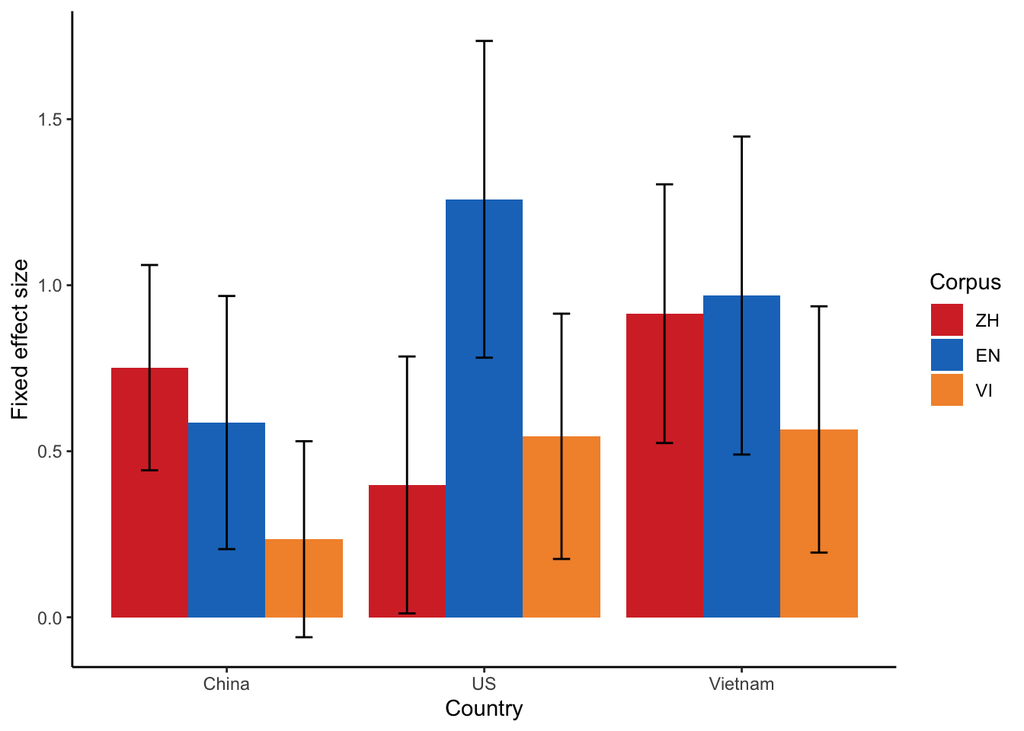

Fixed effect sizes of each corpus when included as a predictor for China, US, and Vietnam responding, respectively. The English corpus is the best predictor for US response, and the Mandarin corpus is the best predictor for China response.

We observed some level of language specificity from this analysis. The English corpus is the best predictor for US responding, and the Mandarin corpus is the best predictor for China response.

```r
fit.country = glmer(responses_theme ~ country + (1 | subject) + (1 | triad),
                           data = df %>% filter(country != "Vietnam"),
                           family = "binomial")

#changed from cosine to frequency proportion
fit.country_corpus = glmer(responses_theme ~ country + theme_freq_prop_E + theme_freq_prop_M + (1 | subject) + (1 | triad),
                           data = df %>% filter(country != "Vietnam"),
                           family = "binomial")

fit.add_corpus <- anova(fit.country, fit.country_corpus, type = 3)
fit.add_corpus
```

```
Data: df %>% filter(country != "Vietnam")
Models:
fit.country: responses_theme ~ country + (1 | subject) + (1 | triad)
fit.country_corpus: responses_theme ~ country + theme_freq_prop_E + theme_freq_prop_M + (1 | subject) + (1 | triad)
                   npar   AIC   BIC logLik deviance  Chisq Df Pr(>Chisq)
fit.country           4 29911 29944 -14951    29903
fit.country_corpus    6 29888 29937 -14938    29876 26.877  2  1.458e-06 ***
---
Signif. codes:  0 '***' 0.001 '**' 0.01 '*' 0.05 '.' 0.1 ' ' 1
```

## Does similarity reasoning differ across cultures, only the input to it, or both?

Does adding country and interaction term with the corresponding corpus improves the model?

```r
df <- df %>%
  mutate(theme_freq_prop_corr_lang = case_when(
    country == "US" ~ theme_freq_prop_E,
    country == "China" ~ theme_freq_prop_M,
    country == "Vietnam" ~ theme_freq_prop_V))

fit.language = glmer(responses_theme ~ theme_freq_prop_corr_lang + (1 | subject) + (1 | triad),
          data = df %>% filter(!(triad %in% triads_omit)),
          family="binomial")
summary(fit.language)
fit.language.anova = Anova(fit.language, type = 3)
fit.language.anova

fit.country_language = glmer(responses_theme ~ theme_freq_prop_corr_lang * country + (1 | subject) + (1 | triad),
          data = df %>% filter(!(triad %in% triads_omit)),
          family="binomial")
summary(fit.country_language)
fit.country_language.anova = Anova(fit.country_language, type = 3)
fit.country_language.anova

fit.country_language_compare = anova(fit.language, fit.country_language, type = 3)
fit.country_language_compare
```

```
Generalized linear mixed model fit by maximum likelihood (Laplace
  Approximation) [glmerMod]
 Family: binomial  ( logit )
Formula: responses_theme ~ theme_freq_prop_corr_lang + (1 | subject) +
    (1 | triad)
   Data: df %>% filter(!(triad %in% triads_omit))

     AIC      BIC   logLik deviance df.resid
 43066.8  43101.0 -21529.4  43058.8    38373

Scaled residuals:
    Min      1Q  Median      3Q     Max
-5.3145 -0.7695  0.3761  0.6684  8.4657

Random effects:
 Groups  Name        Variance Std.Dev.
 subject (Intercept) 0.5564   0.7459
 triad   (Intercept) 0.9155   0.9568
Number of obs: 38377, groups:  subject, 366; triad, 105

Fixed effects:
                          Estimate Std. Error z value Pr(>|z|)
(Intercept)                 0.3789     0.1075   3.526 0.000422 ***
theme_freq_prop_corr_lang   0.2981     0.0589   5.061 4.16e-07 ***
---
Signif. codes:  0 '***' 0.001 '**' 0.01 '*' 0.05 '.' 0.1 ' ' 1

Correlation of Fixed Effects:
            (Intr)
thm_frq_p__ -0.316
Analysis of Deviance Table (Type III Wald chisquare tests)

Response: responses_theme
                           Chisq Df Pr(>Chisq)
(Intercept)               12.431  1  0.0004223 ***
theme_freq_prop_corr_lang 25.616  1  4.165e-07 ***
---
Signif. codes:  0 '***' 0.001 '**' 0.01 '*' 0.05 '.' 0.1 ' ' 1
Generalized linear mixed model fit by maximum likelihood (Laplace
  Approximation) [glmerMod]
```

[output cut: 47 more lines]

```
(Intercept)                       40.7267  1  1.751e-10 ***
theme_freq_prop_corr_lang          0.0543  1     0.8158
country                           51.4931  2  6.583e-12 ***
theme_freq_prop_corr_lang:country 32.8383  2  7.400e-08 ***
---
Signif. codes:  0 '***' 0.001 '**' 0.01 '*' 0.05 '.' 0.1 ' ' 1
Data: df %>% filter(!(triad %in% triads_omit))
Models:
fit.language: responses_theme ~ theme_freq_prop_corr_lang + (1 | subject) + (1 | triad)
fit.country_language: responses_theme ~ theme_freq_prop_corr_lang * country + (1 | subject) + (1 | triad)
                     npar   AIC   BIC logLik deviance  Chisq Df Pr(>Chisq)
fit.language            4 43067 43101 -21529    43059
fit.country_language    8 43014 43083 -21499    42998 60.442  4  2.342e-12 ***
---
Signif. codes:  0 '***' 0.001 '**' 0.01 '*' 0.05 '.' 0.1 ' ' 1
```

Adding country improves the model. Only country and interaction between country and corresponding corpus’s lexical co-occurrence are significant predictors. Corresponding corpus’s lexical co-occurrence is no longer a significant predictor.

##How specific are the cross-language differences in similarity judgments we observe?

###Do we see differential responding across cue items from different semantic domains? Plotting mean response theme by country, by type of triad

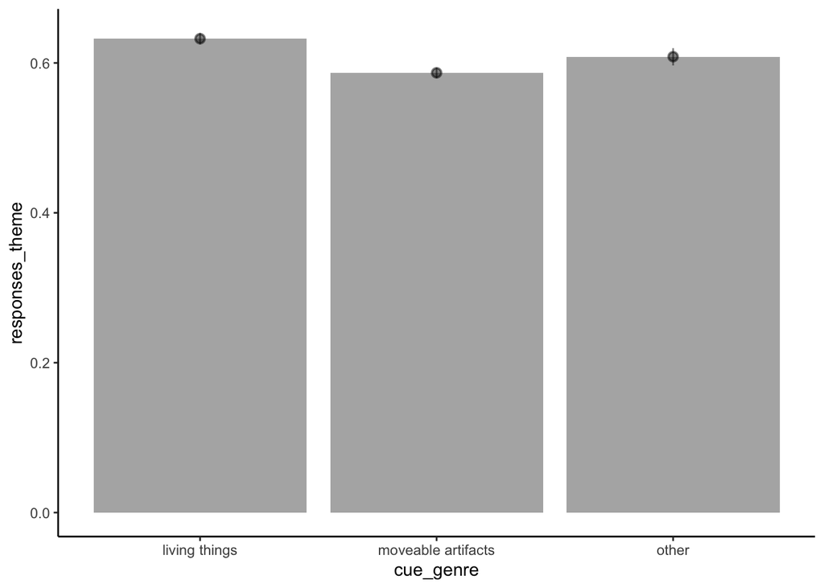

```r
ggplot(data = df) +
   geom_bar(stat = "summary",
            fun.data = "mean_cl_boot",
            alpha = .5,
            mapping = aes(x = cue_genre,
                          y = responses_theme)) +
  geom_pointrange(stat = "summary",
            fun.data = "mean_cl_boot",
            alpha = .5,
            mapping = aes(x = cue_genre,
                          y = responses_theme))
```

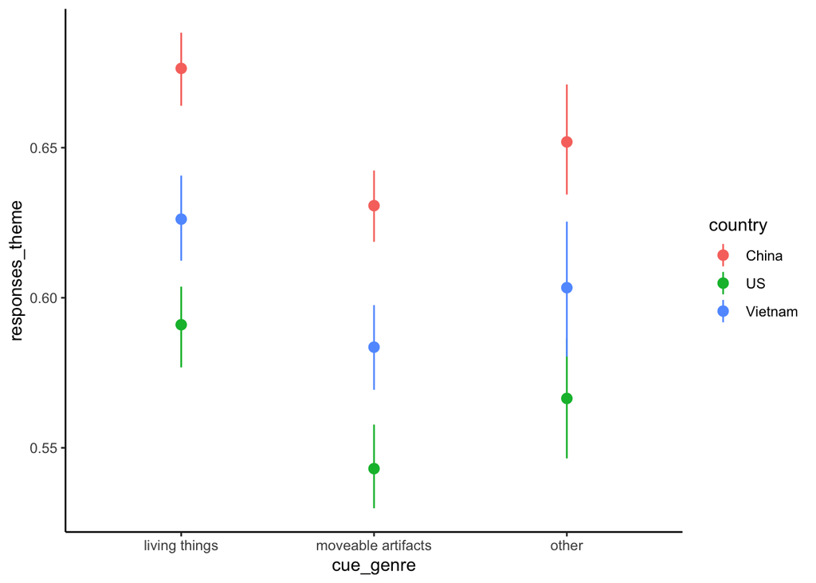

```r
ggplot(data = df,
       mapping = aes(x = cue_genre,
                     y = responses_theme,
                     color = country,
                     fill = country)) +
   stat_summary(fun.data = "mean_cl_boot",
               geom = "pointrange")
#color code by cue genre, spatial sep by country, plotting all triads (mean response)
```

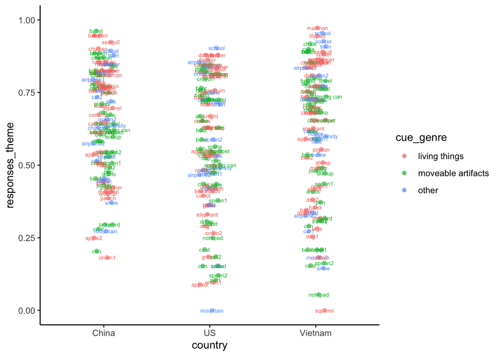

```r
ggplot(data = df,
       mapping = aes(x = country,
                     y = responses_theme,
                     label = triad,
                     group = triad,
                     color = cue_genre)) +
  stat_summary(fun.data = "mean_cl_boot",
               geom = "point",
               alpha = .5,
               position = position_dodge(width = .2)) +
  stat_summary(fun.data = "mean_cl_boot",
               geom = "text",
               position = position_dodge(width = .2), size = 2)
```

There seems to be a preference for more thematic matches in the ‘living things’ cues in comparison to the ‘moveable artifacts’ cue.

Comparing some models (omitting cue_genre = “other”) *should we omit ‘other’ from the analysis?*

### English

Base line model:

```r
# English
fit.EN_US_cue_genre_base = glmer(responses_theme ~ theme_freq_prop_E + (1 | subject) + (1 | triad),
          data = df %>% filter(country == "US",
                               !(triad %in% triads_omit),
                               !(cue_genre == "other")),
          family="binomial")
summary(fit.EN_US_cue_genre_base)
fit.EN_US_cue_genre_base.anova = Anova(fit.EN_US_cue_genre_base, type = 3)
```

```
Generalized linear mixed model fit by maximum likelihood (Laplace
  Approximation) [glmerMod]
 Family: binomial  ( logit )
Formula: responses_theme ~ theme_freq_prop_E + (1 | subject) + (1 | triad)
   Data:
df %>% filter(country == "US", !(triad %in% triads_omit), !(cue_genre ==
    "other"))

     AIC      BIC   logLik deviance df.resid
 11557.2  11586.3  -5774.6  11549.2    10660

Scaled residuals:
    Min      1Q  Median      3Q     Max
-4.5692 -0.6789  0.3207  0.6310 16.2699

Random effects:
 Groups  Name        Variance Std.Dev.
 subject (Intercept) 0.9589   0.9792
 triad   (Intercept) 1.0442   1.0219
Number of obs: 10664, groups:  subject, 124; triad, 86

Fixed effects:
                  Estimate Std. Error z value Pr(>|z|)
(Intercept)        -0.9879     0.2682  -3.684  0.00023 ***
theme_freq_prop_E   2.0465     0.3582   5.713 1.11e-08 ***
---
Signif. codes:  0 '***' 0.001 '**' 0.01 '*' 0.05 '.' 0.1 ' ' 1

Correlation of Fixed Effects:
            (Intr)
thm_frq_p_E -0.846
```

```r
fit.EN_US_cue_genre = glmer(responses_theme ~ theme_freq_prop_E + cue_genre + (1 | subject) + (1 | triad),
          data = df %>% filter(country == "US",
                               !(triad %in% triads_omit),
                               !(cue_genre == "other")),
          family="binomial")

summary(fit.EN_US_cue_genre)
Anova(fit.EN_US_cue_genre, type = 3)
```

```
Generalized linear mixed model fit by maximum likelihood (Laplace
  Approximation) [glmerMod]
 Family: binomial  ( logit )
Formula: responses_theme ~ theme_freq_prop_E + cue_genre + (1 | subject) +
    (1 | triad)
   Data:
df %>% filter(country == "US", !(triad %in% triads_omit), !(cue_genre ==
    "other"))

     AIC      BIC   logLik deviance df.resid
 11556.7  11593.1  -5773.4  11546.7    10659

Scaled residuals:
    Min      1Q  Median      3Q     Max
-4.5886 -0.6804  0.3204  0.6297 16.1341

Random effects:
 Groups  Name        Variance Std.Dev.
 subject (Intercept) 0.9592   0.9794
 triad   (Intercept) 1.0132   1.0066
Number of obs: 10664, groups:  subject, 124; triad, 86

Fixed effects:
                            Estimate Std. Error z value Pr(>|z|)
(Intercept)                  -0.8208     0.2847  -2.883  0.00393 **
theme_freq_prop_E             2.0695     0.3534   5.856 4.73e-09 ***
cue_genremoveable artifacts  -0.3545     0.2227  -1.592  0.11137
---
Signif. codes:  0 '***' 0.001 '**' 0.01 '*' 0.05 '.' 0.1 ' ' 1

Correlation of Fixed Effects:
            (Intr) th___E
thm_frq_p_E -0.769
c_gnrmvblar -0.368 -0.043
Analysis of Deviance Table (Type III Wald chisquare tests)

Response: responses_theme
                    Chisq Df Pr(>Chisq)
(Intercept)        8.3137  1   0.003935 **
theme_freq_prop_E 34.2974  1   4.73e-09 ***
cue_genre          2.5347  1   0.111365
---
Signif. codes:  0 '***' 0.001 '**' 0.01 '*' 0.05 '.' 0.1 ' ' 1
```

```r
fit.EN_US_cue_genre_compare = anova(fit.EN_US_cue_genre_base, fit.EN_US_cue_genre, type = 3)
fit.EN_US_cue_genre_compare
```

```
Data: df %>% filter(country == "US", !(triad %in% triads_omit), !(cue_genre ==  ...
Models:
fit.EN_US_cue_genre_base: responses_theme ~ theme_freq_prop_E + (1 | subject) + (1 | triad)
fit.EN_US_cue_genre: responses_theme ~ theme_freq_prop_E + cue_genre + (1 | subject) + (1 | triad)
                         npar   AIC   BIC  logLik deviance  Chisq Df Pr(>Chisq)
fit.EN_US_cue_genre_base    4 11557 11586 -5774.6    11549
fit.EN_US_cue_genre         5 11557 11593 -5773.4    11547 2.4983  1      0.114
```

### Vietnamese

```r
#Vietnamese
fit.VI_VN_cue_genre_base = glmer(responses_theme ~ theme_freq_prop_V + (1 | subject) + (1 | triad),
          data = df %>% filter(country == "Vietnam",
                               !(triad %in% triads_omit),
                               !(cue_genre == "other")),
          family="binomial")
summary(fit.VI_VN_cue_genre_base)
fit.VI_VN_cue_genre_base.anova = Anova(fit.VI_VN_cue_genre_base, type = 3)
```

```
Generalized linear mixed model fit by maximum likelihood (Laplace
  Approximation) [glmerMod]
 Family: binomial  ( logit )
Formula: responses_theme ~ theme_freq_prop_V + (1 | subject) + (1 | triad)
   Data: df %>% filter(country == "Vietnam", !(triad %in% triads_omit),
    !(cue_genre == "other"))

     AIC      BIC   logLik deviance df.resid
 10243.1  10271.7  -5117.6  10235.1     9404

Scaled residuals:
    Min      1Q  Median      3Q     Max
-5.1887 -0.6825  0.3542  0.6190  4.8616

Random effects:
 Groups  Name        Variance Std.Dev.
 subject (Intercept) 0.4156   0.6447
 triad   (Intercept) 1.4133   1.1888
Number of obs: 9408, groups:  subject, 110; triad, 86

Fixed effects:
                  Estimate Std. Error z value Pr(>|z|)
(Intercept)        -0.1754     0.2330  -0.753    0.452
theme_freq_prop_V   1.4256     0.3660   3.895 9.82e-05 ***
---
Signif. codes:  0 '***' 0.001 '**' 0.01 '*' 0.05 '.' 0.1 ' ' 1

Correlation of Fixed Effects:
            (Intr)
thm_frq_p_V -0.784
```

Adding cue genre: NOT significant

```r
fit.VI_VN_cue_genre = glmer(responses_theme ~ theme_freq_prop_V + cue_genre + (1 | subject) + (1 | triad),
          data = df %>% filter(country == "Vietnam",
                               !(triad %in% triads_omit),
                               !(cue_genre == "other")),
          family="binomial")

summary(fit.VI_VN_cue_genre)
Anova(fit.VI_VN_cue_genre, type = 3)
```

```
Generalized linear mixed model fit by maximum likelihood (Laplace
  Approximation) [glmerMod]
 Family: binomial  ( logit )
Formula: responses_theme ~ theme_freq_prop_V + cue_genre + (1 | subject) +
    (1 | triad)
   Data: df %>% filter(country == "Vietnam", !(triad %in% triads_omit),
    !(cue_genre == "other"))

     AIC      BIC   logLik deviance df.resid
 10242.6  10278.4  -5116.3  10232.6     9403

Scaled residuals:
    Min      1Q  Median      3Q     Max
-5.1556 -0.6836  0.3534  0.6194  4.8999

Random effects:
 Groups  Name        Variance Std.Dev.
 subject (Intercept) 0.4156   0.6446
 triad   (Intercept) 1.3654   1.1685
Number of obs: 9408, groups:  subject, 110; triad, 86

Fixed effects:
                             Estimate Std. Error z value Pr(>|z|)
(Intercept)                 -0.008803   0.251727  -0.035    0.972
theme_freq_prop_V            1.523093   0.365195   4.171 3.04e-05 ***
cue_genremoveable artifacts -0.419474   0.261336  -1.605    0.108
---
Signif. codes:  0 '***' 0.001 '**' 0.01 '*' 0.05 '.' 0.1 ' ' 1

Correlation of Fixed Effects:
            (Intr) th___V
thm_frq_p_V -0.635
c_gnrmvblar -0.411 -0.168
Analysis of Deviance Table (Type III Wald chisquare tests)

Response: responses_theme
                    Chisq Df Pr(>Chisq)
(Intercept)        0.0012  1     0.9721
theme_freq_prop_V 17.3941  1  3.038e-05 ***
cue_genre          2.5764  1     0.1085
---
Signif. codes:  0 '***' 0.001 '**' 0.01 '*' 0.05 '.' 0.1 ' ' 1
```

Anova comparison (also not significant)

```r
fit.VI_VN_cue_genre_compare = anova(fit.VI_VN_cue_genre_base, fit.VI_VN_cue_genre, type = 3)
fit.VI_VN_cue_genre_compare
```

```
Data: df %>% filter(country == "Vietnam", !(triad %in% triads_omit),  ...
Models:
fit.VI_VN_cue_genre_base: responses_theme ~ theme_freq_prop_V + (1 | subject) + (1 | triad)
fit.VI_VN_cue_genre: responses_theme ~ theme_freq_prop_V + cue_genre + (1 | subject) + (1 | triad)
                         npar   AIC   BIC  logLik deviance  Chisq Df Pr(>Chisq)
fit.VI_VN_cue_genre_base    4 10243 10272 -5117.6    10235
fit.VI_VN_cue_genre         5 10243 10278 -5116.3    10233 2.5311  1     0.1116
```

### Mandarin

```r
#Mandarin
fit.ZH_CN_cue_genre_base = glmer(responses_theme ~ theme_freq_prop_M + (1 | subject) + (1 | triad),
          data = df %>% filter(country == "China",
                               !(triad %in% triads_omit),
                               !(cue_genre == "other")),
          family="binomial")
summary(fit.ZH_CN_cue_genre_base)
fit.ZH_CN_cue_genre_base.anova = Anova(fit.ZH_CN_cue_genre_base, type = 3)
```

```
Generalized linear mixed model fit by maximum likelihood (Laplace
  Approximation) [glmerMod]
 Family: binomial  ( logit )
Formula: responses_theme ~ theme_freq_prop_M + (1 | subject) + (1 | triad)
   Data: df %>% filter(country == "China", !(triad %in% triads_omit),
    !(cue_genre == "other"))

     AIC      BIC   logLik deviance df.resid
 12641.4  12670.7  -6316.7  12633.4    11348

Scaled residuals:
    Min      1Q  Median      3Q     Max
-4.7880 -0.7805  0.3886  0.6408  3.5061

Random effects:
 Groups  Name        Variance Std.Dev.
 subject (Intercept) 0.3834   0.6192
 triad   (Intercept) 0.8107   0.9004
Number of obs: 11352, groups:  subject, 132; triad, 86

Fixed effects:
                  Estimate Std. Error z value Pr(>|z|)
(Intercept)        0.07638    0.20049   0.381    0.703
theme_freq_prop_M  1.24991    0.28531   4.381 1.18e-05 ***
---
Signif. codes:  0 '***' 0.001 '**' 0.01 '*' 0.05 '.' 0.1 ' ' 1

Correlation of Fixed Effects:
            (Intr)
thm_frq_p_M -0.824
```

Adding cue genre: significant

```r
fit.ZH_CN_cue_genre = glmer(responses_theme ~ theme_freq_prop_M + cue_genre + (1 | subject) + (1 | triad),
          data = df %>% filter(country == "China",
                               !(triad %in% triads_omit),
                               !(cue_genre == "other")),
          family="binomial")

summary(fit.ZH_CN_cue_genre)
Anova(fit.ZH_CN_cue_genre, type = 3)
```

```
Generalized linear mixed model fit by maximum likelihood (Laplace
  Approximation) [glmerMod]
 Family: binomial  ( logit )
Formula: responses_theme ~ theme_freq_prop_M + cue_genre + (1 | subject) +
    (1 | triad)
   Data: df %>% filter(country == "China", !(triad %in% triads_omit),
    !(cue_genre == "other"))

     AIC      BIC   logLik deviance df.resid
 12635.5  12672.2  -6312.7  12625.5    11347

Scaled residuals:
    Min      1Q  Median      3Q     Max
-4.6552 -0.7820  0.3885  0.6402  3.4915

Random effects:
 Groups  Name        Variance Std.Dev.
 subject (Intercept) 0.3832   0.6191
 triad   (Intercept) 0.7359   0.8579
Number of obs: 11352, groups:  subject, 132; triad, 86

Fixed effects:
                            Estimate Std. Error z value Pr(>|z|)
(Intercept)                   0.2285     0.1993   1.147  0.25150
theme_freq_prop_M             1.4933     0.2858   5.225 1.74e-07 ***
cue_genremoveable artifacts  -0.5737     0.2001  -2.867  0.00415 **
---
Signif. codes:  0 '***' 0.001 '**' 0.01 '*' 0.05 '.' 0.1 ' ' 1

Correlation of Fixed Effects:
            (Intr) th___M
thm_frq_p_M -0.675
c_gnrmvblar -0.266 -0.301
Analysis of Deviance Table (Type III Wald chisquare tests)

Response: responses_theme
                    Chisq Df Pr(>Chisq)
(Intercept)        1.3150  1   0.251496
theme_freq_prop_M 27.2990  1  1.743e-07 ***
cue_genre          8.2183  1   0.004147 **
---
Signif. codes:  0 '***' 0.001 '**' 0.01 '*' 0.05 '.' 0.1 ' ' 1
```

Anova comparison: including cue genre is a better model

```r
fit.ZH_CN_cue_genre_compare = anova(fit.ZH_CN_cue_genre_base, fit.ZH_CN_cue_genre, type = 3)
fit.ZH_CN_cue_genre_compare
```

```
Data: df %>% filter(country == "China", !(triad %in% triads_omit),  ...
Models:
fit.ZH_CN_cue_genre_base: responses_theme ~ theme_freq_prop_M + (1 | subject) + (1 | triad)
fit.ZH_CN_cue_genre: responses_theme ~ theme_freq_prop_M + cue_genre + (1 | subject) + (1 | triad)
                         npar   AIC   BIC  logLik deviance  Chisq Df Pr(>Chisq)
fit.ZH_CN_cue_genre_base    4 12641 12671 -6316.7    12633
fit.ZH_CN_cue_genre         5 12636 12672 -6312.7    12626 7.8576  1   0.005061

fit.ZH_CN_cue_genre_base
fit.ZH_CN_cue_genre      **
---
Signif. codes:  0 '***' 0.001 '**' 0.01 '*' 0.05 '.' 0.1 ' ' 1
```

###Do we see differential responding across distinct types of thematic relationships? Plotting mean response theme by country, by type of thematic match

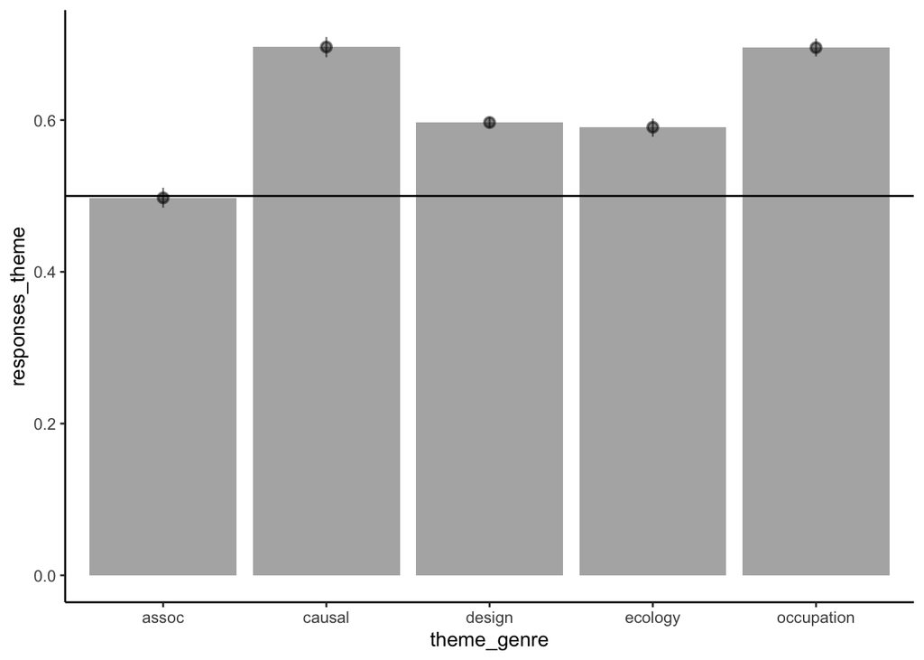

```r
ggplot(data = df) +
   geom_bar(stat = "summary",
            fun.data = "mean_cl_boot",
            alpha = .5,
            mapping = aes(x = theme_genre,
                          y = responses_theme)) +
  geom_pointrange(stat = "summary",
            fun.data = "mean_cl_boot",
            alpha = .5,
            mapping = aes(x = theme_genre,
                          y = responses_theme)) +
  geom_hline(yintercept = 0.5)
```

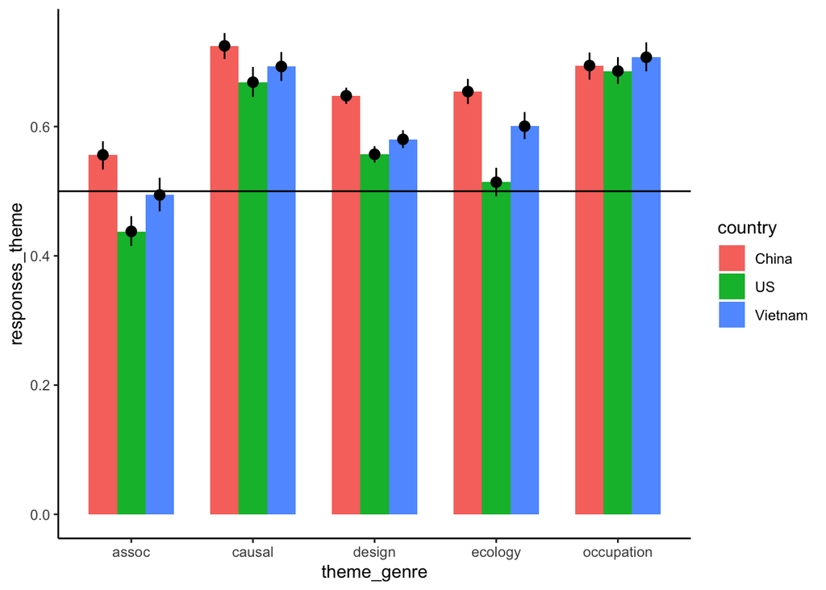

```r
ggplot(data = df) +
   geom_bar(stat = "summary",
            fun.data = "mean_cl_boot",
            mapping = aes(x = theme_genre,
                          y = responses_theme,
                          fill = country),
            position = position_dodge(width = .7), width = .7) +
  geom_pointrange(stat = "summary",
            fun.data = "mean_cl_boot",
            mapping = aes(x = theme_genre,
                          y = responses_theme,
                          group = country),
            position = position_dodge(width = .7)) +
  geom_hline(yintercept = 0.5)
#color code by cue genre, spatial sep by country, plotting all triads (mean response)
```

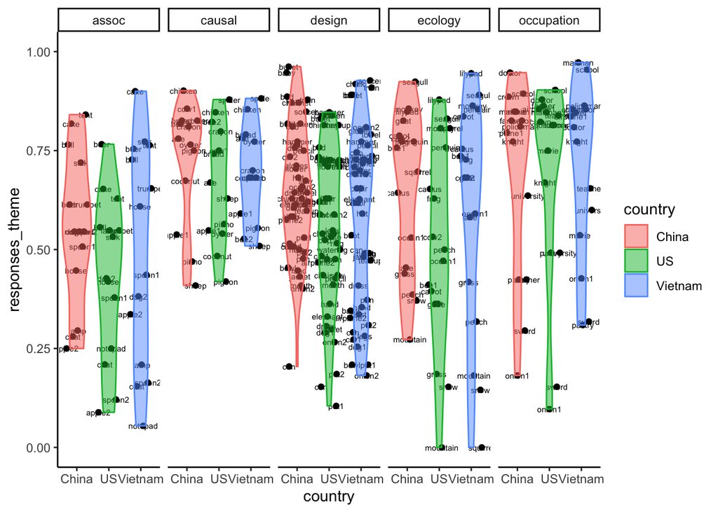

```r
ggplot(data = df,
       mapping = aes(x = country,
                     y = responses_theme,
                     label = triad,
                     group = triad)) +
  geom_point(stat = "summary",
             fun.data = "mean_cl_boot",
             position = position_dodge(width = .7)) +
  geom_text(stat = "summary",
            fun.data = "mean_cl_boot",
            color = alpha('black'),
            position = position_dodge(width = .7), size = 2) +
  geom_violin(data = df %>%
                group_by(country, theme_genre, triad) %>%
                summarize(theme_resp_triad = mean(responses_theme, na.rm = T)),
                mapping = aes(x = country,
                              y = theme_resp_triad,
                              group = country,
                              fill = country,
                              color = country),
                alpha = .5) +
  facet_grid(~theme_genre)
# geom_point(data = df %>% filter(theme_genre == 'ecology'),
#            mapping = aes(x = country,
#                    y = responses_theme,
#                    label = triad,
#                    group = triad,
#                    color = theme_genre),
#            stat = "summary",
#            fun.data = "mean_cl_boot",
#            position = position_dodge(width =.7))
```

### English

Base line model:

```r
# English
fit.EN_US_theme_genre_base = glmer(responses_theme ~ theme_freq_prop_E + (1 | subject) + (1 | triad),
          data = df %>% filter(country == "US",
                               !(triad %in% triads_omit)),
          family="binomial")
summary(fit.EN_US_theme_genre_base)
fit.EN_US_theme_genre_base.anova = Anova(fit.EN_US_theme_genre_base, type = 3)
```

```
Generalized linear mixed model fit by maximum likelihood (Laplace
  Approximation) [glmerMod]
 Family: binomial  ( logit )
Formula: responses_theme ~ theme_freq_prop_E + (1 | subject) + (1 | triad)
   Data: df %>% filter(country == "US", !(triad %in% triads_omit))

     AIC      BIC   logLik deviance df.resid
 13974.4  14004.3  -6983.2  13966.4    13015

Scaled residuals:
    Min      1Q  Median      3Q     Max
-4.9495 -0.6809  0.3121  0.6286 15.4590

Random effects:
 Groups  Name        Variance Std.Dev.
 subject (Intercept) 0.9915   0.9957
 triad   (Intercept) 1.2845   1.1333
Number of obs: 13019, groups:  subject, 124; triad, 105

Fixed effects:
                  Estimate Std. Error z value Pr(>|z|)
(Intercept)        -0.8541     0.2711  -3.151  0.00163 **
theme_freq_prop_E   1.8414     0.3677   5.008  5.5e-07 ***
---
Signif. codes:  0 '***' 0.001 '**' 0.01 '*' 0.05 '.' 0.1 ' ' 1

Correlation of Fixed Effects:
            (Intr)
thm_frq_p_E -0.847
```

Adding theme genre: significant

```r
fit.EN_US_theme_genre = glmer(responses_theme ~ theme_freq_prop_E + theme_genre + (1 | subject) + (1 | triad),
          data = df %>% filter(country == "US",
                               !(triad %in% triads_omit)),
          family="binomial")

summary(fit.EN_US_theme_genre)
fit.EN_US_theme_genre.anova = Anova(fit.EN_US_theme_genre, type = 3)
```

```
Generalized linear mixed model fit by maximum likelihood (Laplace
  Approximation) [glmerMod]
 Family: binomial  ( logit )
Formula: responses_theme ~ theme_freq_prop_E + theme_genre + (1 | subject) +
    (1 | triad)
   Data: df %>% filter(country == "US", !(triad %in% triads_omit))

     AIC      BIC   logLik deviance df.resid
 13969.6  14029.4  -6976.8  13953.6    13011

Scaled residuals:
    Min      1Q  Median      3Q     Max
-5.0310 -0.6792  0.3111  0.6294 15.7188

Random effects:
 Groups  Name        Variance Std.Dev.
 subject (Intercept) 0.992    0.996
 triad   (Intercept) 1.128    1.062
Number of obs: 13019, groups:  subject, 124; triad, 105

Fixed effects:
                      Estimate Std. Error z value Pr(>|z|)
(Intercept)            -1.4567     0.3706  -3.931 8.46e-05 ***
theme_freq_prop_E       1.7346     0.3568   4.862 1.16e-06 ***
theme_genrecausal       0.9901     0.4226   2.343  0.01914 *
theme_genredesign       0.7317     0.3315   2.207  0.02731 *
theme_genreecology      0.2691     0.3934   0.684  0.49399
theme_genreoccupation   1.2858     0.4063   3.164  0.00155 **
---
Signif. codes:  0 '***' 0.001 '**' 0.01 '*' 0.05 '.' 0.1 ' ' 1

Correlation of Fixed Effects:
            (Intr) th___E thm_gnrcs thm_gnrd thm_gnrcl
thm_frq_p_E -0.573
them_gnrcsl -0.455 -0.143
thm_gnrdsgn -0.708  0.040  0.595
thm_gnrclgy -0.542 -0.061  0.515     0.643
thm_gnrccpt -0.510 -0.085  0.503     0.621    0.532
```

Anova comparison: including theme genre is a better model

```r
fit.EN_US_theme_genre_compare = anova(fit.EN_US_theme_genre_base, fit.EN_US_theme_genre, type = 3)
fit.EN_US_theme_genre_compare
```

```
Data: df %>% filter(country == "US", !(triad %in% triads_omit))
Models:
fit.EN_US_theme_genre_base: responses_theme ~ theme_freq_prop_E + (1 | subject) + (1 | triad)
fit.EN_US_theme_genre: responses_theme ~ theme_freq_prop_E + theme_genre + (1 | subject) + (1 | triad)
                           npar   AIC   BIC  logLik deviance  Chisq Df
fit.EN_US_theme_genre_base    4 13974 14004 -6983.2    13966
fit.EN_US_theme_genre         8 13970 14029 -6976.8    13954 12.797  4
                           Pr(>Chisq)
fit.EN_US_theme_genre_base
fit.EN_US_theme_genre         0.01231 *
---
Signif. codes:  0 '***' 0.001 '**' 0.01 '*' 0.05 '.' 0.1 ' ' 1
```

### Vietnamese

```r
#Vietnamese
fit.VI_VN_theme_genre_base = glmer(responses_theme ~ theme_freq_prop_V + (1 | subject) + (1 | triad),
          data = df %>% filter(country == "Vietnam",
                               !(triad %in% triads_omit)),
          family="binomial")
summary(fit.VI_VN_theme_genre_base)
fit.VI_VN_theme_genre_base.anova = Anova(fit.VI_VN_theme_genre_base, type = 3)
```

```
Generalized linear mixed model fit by maximum likelihood (Laplace
  Approximation) [glmerMod]
 Family: binomial  ( logit )
Formula: responses_theme ~ theme_freq_prop_V + (1 | subject) + (1 | triad)
   Data: df %>% filter(country == "Vietnam", !(triad %in% triads_omit))

     AIC      BIC   logLik deviance df.resid
 12500.4  12529.8  -6246.2  12492.4    11494

Scaled residuals:
    Min      1Q  Median      3Q     Max
-6.0825 -0.6792  0.3462  0.6219  5.1543

Random effects:
 Groups  Name        Variance Std.Dev.
 subject (Intercept) 0.3819   0.618
 triad   (Intercept) 1.4565   1.207
Number of obs: 11498, groups:  subject, 110; triad, 105

Fixed effects:
                  Estimate Std. Error z value Pr(>|z|)
(Intercept)        -0.1247     0.2148  -0.580    0.562
theme_freq_prop_V   1.3339     0.3361   3.969 7.21e-05 ***
---
Signif. codes:  0 '***' 0.001 '**' 0.01 '*' 0.05 '.' 0.1 ' ' 1

Correlation of Fixed Effects:
            (Intr)
thm_frq_p_V -0.782
```

Adding theme genre: not significant

```r
fit.VI_VN_theme_genre = glmer(responses_theme ~ theme_freq_prop_V + theme_genre + (1 | subject) + (1 | triad),
          data = df %>% filter(country == "Vietnam",
                               !(triad %in% triads_omit)),
          family="binomial")

summary(fit.VI_VN_theme_genre)
fit.VI_VN_theme_genre.anova = Anova(fit.VI_VN_theme_genre, type = 3)
```

```
Generalized linear mixed model fit by maximum likelihood (Laplace
  Approximation) [glmerMod]
 Family: binomial  ( logit )
Formula: responses_theme ~ theme_freq_prop_V + theme_genre + (1 | subject) +
    (1 | triad)
   Data: df %>% filter(country == "Vietnam", !(triad %in% triads_omit))

     AIC      BIC   logLik deviance df.resid
 12499.9  12558.7  -6241.9  12483.9    11490

Scaled residuals:
    Min      1Q  Median      3Q     Max
-6.1831 -0.6812  0.3468  0.6223  5.2815

Random effects:
 Groups  Name        Variance Std.Dev.
 subject (Intercept) 0.3819   0.618
 triad   (Intercept) 1.3351   1.155
Number of obs: 11498, groups:  subject, 110; triad, 105

Fixed effects:
                      Estimate Std. Error z value Pr(>|z|)
(Intercept)            -0.8390     0.3759  -2.232   0.0256 *
theme_freq_prop_V       1.3037     0.3322   3.925 8.68e-05 ***
theme_genrecausal       1.1196     0.4557   2.457   0.0140 *
theme_genredesign       0.6944     0.3642   1.907   0.0566 .
theme_genreecology      0.7411     0.4311   1.719   0.0856 .
theme_genreoccupation   1.1683     0.4419   2.644   0.0082 **
---
Signif. codes:  0 '***' 0.001 '**' 0.01 '*' 0.05 '.' 0.1 ' ' 1

Correlation of Fixed Effects:
            (Intr) th___V thm_gnrcs thm_gnrd thm_gnrcl
thm_frq_p_V -0.517
them_gnrcsl -0.613  0.054
thm_gnrdsgn -0.799  0.130  0.611
thm_gnrclgy -0.680  0.120  0.517     0.654
thm_gnrccpt -0.570 -0.064  0.495     0.615    0.518
```

Anova comparison: not significant

```r
fit.VI_VN_theme_genre_compare = anova(fit.VI_VN_theme_genre_base, fit.VI_VN_theme_genre, type = 3)
fit.VI_VN_theme_genre_compare
```

```
Data: df %>% filter(country == "Vietnam", !(triad %in% triads_omit))
Models:
fit.VI_VN_theme_genre_base: responses_theme ~ theme_freq_prop_V + (1 | subject) + (1 | triad)
fit.VI_VN_theme_genre: responses_theme ~ theme_freq_prop_V + theme_genre + (1 | subject) + (1 | triad)
                           npar   AIC   BIC  logLik deviance  Chisq Df
fit.VI_VN_theme_genre_base    4 12500 12530 -6246.2    12492
fit.VI_VN_theme_genre         8 12500 12559 -6241.9    12484 8.4979  4
                           Pr(>Chisq)
fit.VI_VN_theme_genre_base
fit.VI_VN_theme_genre         0.07495 .
---
Signif. codes:  0 '***' 0.001 '**' 0.01 '*' 0.05 '.' 0.1 ' ' 1
```